# Part I - Airline delay Dataset Exploration

## Introduction

> This dataset is mainly focused on the various types of delays and the duration of these delay. it is an extensive database of over 20 years. Data is categorised based on the carrier,airport and carrier code.

year: The year of the data record, indicating when the flight occurred. month: The month of the data record, indicating when the flight occurred. carrier: The airline carrier code, representing the airline responsible for the flight. carrier_name: The name of the airline carrier. airport: The airport code, representing the departure or arrival airport. airport_name: The name of the airport. arr_flights: The total number of flights that arrived at the airport. arr_del15: The number of flights that arrived 15 minutes or more late. carrier_ct: The number of flights delayed due to carrier-related issues. weather_ct: The number of flights delayed due to weather-related issues. nas_ct: The number of flights delayed due to National Aviation System (NAS) issues. security_ct: The number of flights delayed due to security-related issues. late_aircraft_ct: The number of flights delayed due to late aircraft arrival. arr_cancelled: The number of flights that were canceled. arr_diverted: The number of flights that were diverted to an alternative airport. arr_delay: The total number of minutes of arrival delay for all flights. carrier_delay: The total number of minutes of arrival delay attributed to carrier issues. weather_delay: The total number of minutes of arrival delay attributed to weather-related issues. nas_delay: The total number of minutes of arrival delay attributed to NAS issues. security_delay: The total number of minutes of arrival delay attributed to security-related issues. late_aircraft_delay: The total number of minutes of arrival delay attributed to late aircraft arrival.

## Preliminary Wrangling

Dataset looks clean and tidy. only few values are missing. since we have lots of data we can safely drop those rows

```python
import numpy as np
import pandas as pd
import matplotlib.pyplot as plt
import seaborn as sb

%matplotlib inline
```

```python
df=pd.read_csv('Airline_Delay_Cause.csv')
df.dropna(inplace=True)
df.info()
```

```
<class 'pandas.core.frame.DataFrame'>
Int64Index: 338371 entries, 0 to 339105
Data columns (total 21 columns):
year                   338371 non-null int64
month                  338371 non-null int64
carrier                338371 non-null object
carrier_name           338371 non-null object
airport                338371 non-null object
airport_name           338371 non-null object
arr_flights            338371 non-null float64
arr_del15              338371 non-null float64
carrier_ct             338371 non-null float64
weather_ct             338371 non-null float64
nas_ct                 338371 non-null float64
security_ct            338371 non-null float64
late_aircraft_ct       338371 non-null float64
arr_cancelled          338371 non-null float64
arr_diverted           338371 non-null float64
arr_delay              338371 non-null float64
carrier_delay          338371 non-null float64
weather_delay          338371 non-null float64
nas_delay              338371 non-null float64
security_delay         338371 non-null float64
late_aircraft_delay    338371 non-null float64
dtypes: float64(15), int64(2), object(4)
memory usage: 56.8+ MB
```

```python
df.head(10)
```

|  | year | month | carrier | carrier_name | airport | airport_name | arr_flights | arr_del15 | carrier_ct | weather_ct | ... | security_ct | late_aircraft_ct | arr_cancelled | arr_diverted | arr_delay | carrier_delay | weather_delay | nas_delay | security_delay | late_aircraft_delay |
| --- | --- | --- | --- | --- | --- | --- | --- | --- | --- | --- | --- | --- | --- | --- | --- | --- | --- | --- | --- | --- | --- |
| 0 | 2023 | 4 | 9E | Endeavor Air Inc. | ABY | Albany, GA: Southwest Georgia Regional | 85.0 | 7.0 | 3.00 | 0.00 | ... | 0.0 | 0.92 | 0.0 | 2.0 | 428.0 | 250.0 | 0.0 | 87.0 | 0.0 | 91.0 |
| 1 | 2023 | 4 | 9E | Endeavor Air Inc. | AEX | Alexandria, LA: Alexandria International | 46.0 | 5.0 | 3.63 | 0.61 | ... | 0.0 | 0.00 | 0.0 | 1.0 | 272.0 | 153.0 | 67.0 | 52.0 | 0.0 | 0.0 |
| 2 | 2023 | 4 | 9E | Endeavor Air Inc. | AGS | Augusta, GA: Augusta Regional at Bush Field | 61.0 | 5.0 | 0.68 | 0.07 | ... | 0.0 | 0.93 | 0.0 | 1.0 | 204.0 | 36.0 | 2.0 | 141.0 | 0.0 | 25.0 |
| 3 | 2023 | 4 | 9E | Endeavor Air Inc. | ALB | Albany, NY: Albany International | 211.0 | 29.0 | 9.86 | 1.00 | ... | 0.0 | 13.93 | 1.0 | 0.0 | 1346.0 | 384.0 | 39.0 | 115.0 | 0.0 | 808.0 |
| 4 | 2023 | 4 | 9E | Endeavor Air Inc. | ATL | Atlanta, GA: Hartsfield-Jackson Atlanta Intern... | 1390.0 | 140.0 | 41.20 | 5.11 | ... | 0.0 | 64.59 | 0.0 | 2.0 | 12486.0 | 4655.0 | 403.0 | 1190.0 | 0.0 | 6238.0 |
| 5 | 2023 | 4 | 9E | Endeavor Air Inc. | ATW | Appleton, WI: Appleton International | 17.0 | 3.0 | 2.89 | 0.00 | ... | 0.0 | 0.00 | 0.0 | 0.0 | 273.0 | 255.0 | 0.0 | 18.0 | 0.0 | 0.0 |
| 6 | 2023 | 4 | 9E | Endeavor Air Inc. | AUS | Austin, TX: Austin - Bergstrom International | 51.0 | 8.0 | 2.91 | 0.00 | ... | 0.0 | 0.00 | 0.0 | 0.0 | 297.0 | 180.0 | 0.0 | 117.0 | 0.0 | 0.0 |
| 7 | 2023 | 4 | 9E | Endeavor Air Inc. | AVL | Asheville, NC: Asheville Regional | 56.0 | 9.0 | 3.47 | 0.00 | ... | 0.0 | 4.54 | 0.0 | 0.0 | 712.0 | 288.0 | 0.0 | 38.0 | 0.0 | 386.0 |
| 8 | 2023 | 4 | 9E | Endeavor Air Inc. | AZO | Kalamazoo, MI: Kalamazoo/Battle Creek Internat... | 60.0 | 4.0 | 1.88 | 0.00 | ... | 0.0 | 1.12 | 0.0 | 0.0 | 359.0 | 124.0 | 0.0 | 81.0 | 0.0 | 154.0 |
| 9 | 2023 | 4 | 9E | Endeavor Air Inc. | BDL | Hartford, CT: Bradley International | 75.0 | 9.0 | 4.21 | 0.00 | ... | 0.0 | 3.61 | 0.0 | 0.0 | 404.0 | 87.0 | 0.0 | 61.0 | 0.0 | 256.0 |

10 rows × 21 columns

### What is the structure of your dataset?

> there are 339106 rows and 21 columns in dataset data types are float, object and int 64 there are null values as well. considering the large quantity of data and very few null values, we can safely discard them

### What is/are the main feature(s) of interest in your dataset?

> Flight counts (arrived, delayed, canceled). Delay categories (carrier, weather, NAS, security, late aircraft). Total delay time and its components. Flight trends over time. Carrier performance.

### What features in the dataset do you think will help support your investigation into your feature(s) of interest?

> Flight counts: arr_flights, arr_del15, arr_cancelled Delay categories: carrier_ct, weather_ct, nas_ct, security_ct, late_aircraft_ct Total delay time: arr_delay, carrier_delay, weather_delay, nas_delay, security_delay, late_aircraft_delay Flight trends over time: year, month Carrier performance: carrier_name

## Univariate Exploration

**What is the distribution of flight delays for all airlines in the dataset?.**

```
(-60, 4000)
```

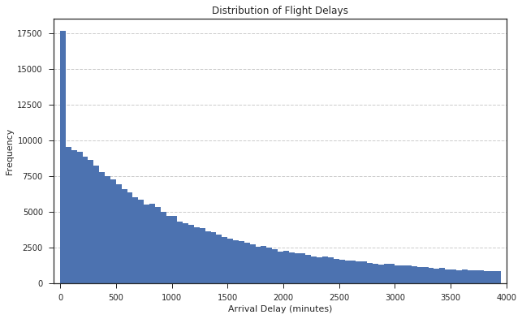

```python
#What is the distribution of flight delays for all airlines in the dataset?

# Define the bin intervals for the histogram
bins=np.arange(0,4000,50)
plt.figure(figsize=(10, 6))
plt.hist(df['arr_delay'],bins=bins)
plt.xlabel('Arrival Delay (minutes)')
plt.ylabel('Frequency')
plt.title('Distribution of Flight Delays')
#Add a horizontal grid for better readability
plt.grid(axis='y', linestyle='--', alpha=1)
plt.xlim(-60,4000)
```

**Which airline has the highest number of flights arrived?**

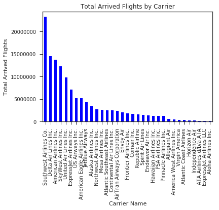

```python
#Which airline has the highest number of flights arrived?
flight_arrived=df.groupby('carrier_name')['arr_flights'].sum()
#Sort the carriers in descending order based on the total arrived flights
flight_arrived_sorted=flight_arrived.sort_values(ascending=False)
flight_arrived_sorted.plot(kind='bar',color='blue')
plt.xlabel('Carrier Name')
plt.ylabel('Total Arrived Flights')
plt.title('Total Arrived Flights by Carrier')
plt.xticks(rotation=90);
plt.ticklabel_format(style='plain', axis='y')
```

> Different carriers have varying total arrived flights, indicating differences in market share and scale. South west airlines has the most arrived flights

**What is the distribution of flight cancellations?**

```
Text(0.5,1,'Total Cancelled Flights by Year (Descending Order)')
```

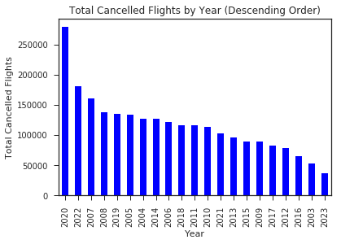

```python
#What is the distribution of flight cancellations?
flight_cancelled=df.groupby('year')['arr_cancelled'].sum()
flight_cancelled_sorted=flight_cancelled.sort_values(ascending=False)
flight_cancelled_sorted.plot(kind='bar',color='blue')
plt.xlabel('Year')
plt.ylabel('Total Cancelled Flights')
plt.title('Total Cancelled Flights by Year (Descending Order)')
```

> 2020 has the most cancelled history. it may be due to the pandemic

**What are the most common reasons for flight delays (e.g., weather, carrier, NAS)?**

```
Text(0.5,1,'Total Delays by Delay Type (Descending Order)')
```

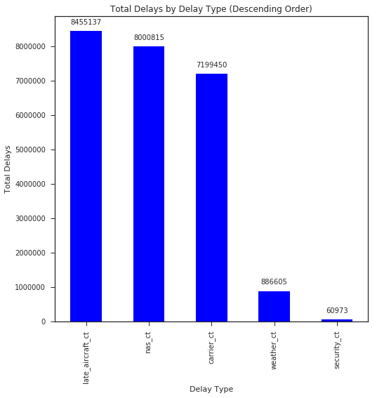

```python
#What are the most common reasons for flight delays (e.g., weather, carrier, NAS)?
delay_counts = df[['carrier_ct', 'weather_ct', 'nas_ct', 'security_ct', 'late_aircraft_ct']].sum()
delay_counts_sorted = delay_counts.sort_values(ascending=False)

# Add labels with the total delay counts on top of each bar
fig3=delay_counts_sorted.plot(kind='bar',color='blue', figsize=(8, 8))
for i,v in enumerate(delay_counts_sorted):
    fig3.text(i,v+250000,str(int(v)),ha='center',va='center')

plt.xlabel('Delay Type')
plt.ylabel('Total Delays')
plt.title('Total Delays by Delay Type (Descending Order)')
```

```
Text(0.5,1,'Distribution of Flights over the years')
```

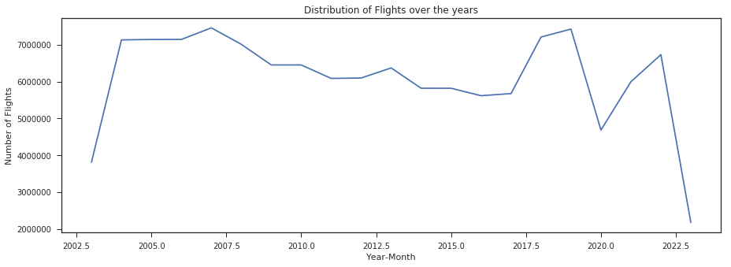

```python
#What is the distribution of the number of flights per month?

#Group the data by year and calculate the sum of arrived flights for each year
flights_per_month = df.groupby('year')['arr_flights'].sum()

flights_per_month.plot(kind='line', figsize=(15, 5))

plt.xlabel('Year-Month')
plt.ylabel('Number of Flights')
plt.title('Distribution of Flights over the years')
```

> period between 2007 and 2017 has seen a drop in total number of flights, reason for it has to be investigated further

**Which month has the highest number of cancelled flights?**

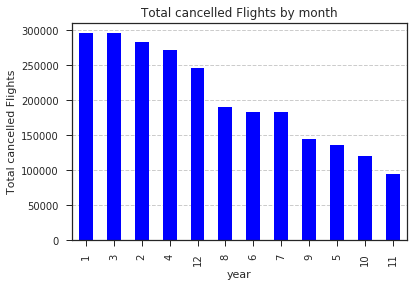

```python
#Which month has the highest number of cancelled flights?
flight_cancelled=df.groupby('month')['arr_cancelled'].sum()
flight_cancelled_sorted=flight_cancelled.sort_values(ascending=False)
flight_cancelled_sorted.plot(kind='bar',color='blue')
plt.xlabel('year')
plt.ylabel('Total cancelled Flights')
plt.title('Total cancelled Flights by month')
plt.xticks(rotation=90);
plt.grid(axis='y', linestyle='--', alpha=1)
```

> November month has the least amount of cancellations while january has the month

### Discuss the distribution(s) of your variable(s) of interest. Were there any unusual points? Did you need to perform any transformations?

> The dataset features variables related to flight counts, delays, and cancellations. The distributions are typically right-skewed, with no unusual points or transformations needed for the main analysis.

### Of the features you investigated, were there any unusual distributions? Did you perform any operations on the data to tidy, adjust, or change the form of the data? If so, why did you do this?

> No, there were no unusual distributions among the features investigated, only null values are dropped on the data to tidy or adjust it. The dataset was relatively clean and straightforward for analysis.

## Bivariate Exploration

> In this section, investigate relationships between pairs of variables in your data. Make sure the variables that you cover here have been introduced in some fashion in the previous section (univariate exploration).

**Do certain months have high arrival count than others**

```
Text(0.5,1,'months of the year')
```

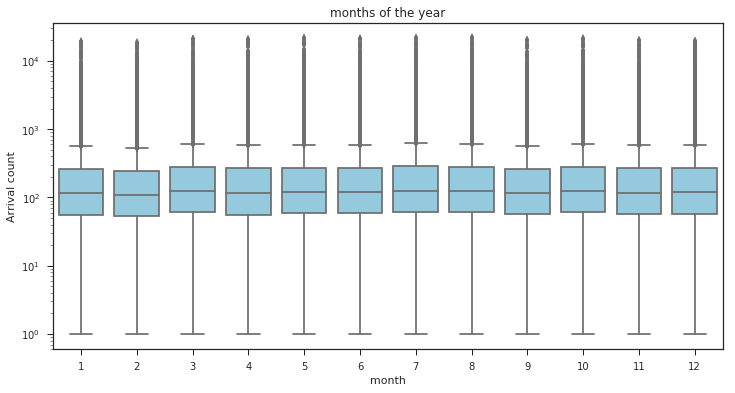

```python
# Do certain months have high arrival count than others
plt.figure(figsize=(12, 6))
sb.boxplot(data=df, x='month', y='arr_flights',color='skyblue');
# Set the y-axis to a logarithmic scale for better visualization
plt.yscale('log')
plt.ylabel('Arrival count')
plt.title('months of the year')
```

> There is not a much deviation in flight arrival over the different months.suggesting flight arrivals are not cyclical

**what is the Relationship between the number of flight arrivals and delayed flights**

```
Text(0.5,1,'Number of Flight Arrivals vs. Number of Delayed Flights')
```

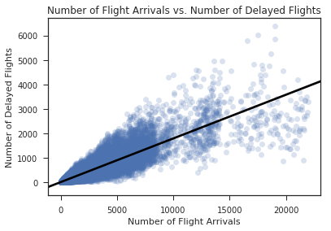

```python
# This scatter plot with a regression line shows the relationship between the number of flight arrivals and delayed flights.

# Create a scatter plot with a regression line
sb.regplot(x='arr_flights',y='arr_del15',data=df,scatter_kws={'alpha':0.2},line_kws={'color':'black'});
plt.xlabel('Number of Flight Arrivals')
plt.ylabel('Number of Delayed Flights')
plt.title('Number of Flight Arrivals vs. Number of Delayed Flights')
```

> There is a strong positive corelation between the Number of Flight Arrivals and Number of Delayed Flights

**Is there a relation between carrier delays and weather delays**

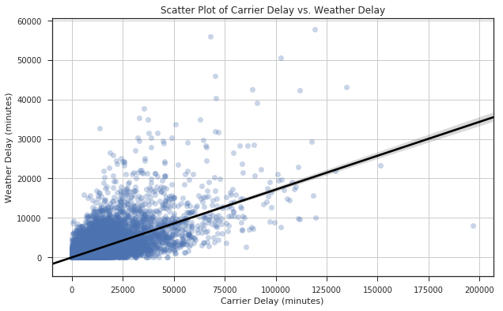

```python
# This scatter plot with a regression line compares carrier delays and weather delays.

# Create a scatter plot with a regression line
plt.figure(figsize=(10, 6))
sb.regplot(df['carrier_delay'], df['weather_delay'], scatter_kws={'alpha':0.3},line_kws={'color':'black'})
plt.xlabel('Carrier Delay (minutes)')
plt.ylabel('Weather Delay (minutes)')
plt.title('Scatter Plot of Carrier Delay vs. Weather Delay')
plt.grid(True)

plt.show()
```

> similarly there is also positive corelation between Carrier Delay and Weather Delay

**How different factors are contributing to delay**

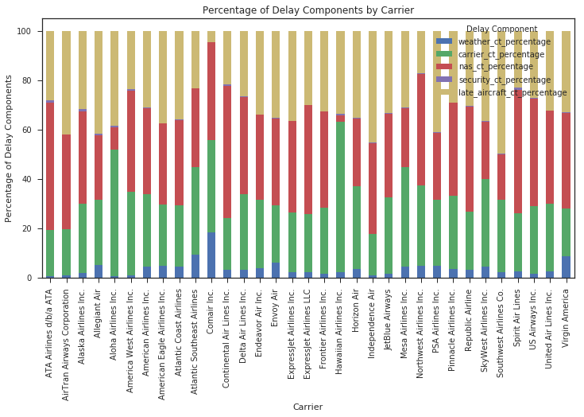

```python
# Group the data by carrier and calculate the sum of various delay components
grouped = df.groupby('carrier_name')[['weather_ct', 'carrier_ct', 'nas_ct', 'security_ct', 'late_aircraft_ct','arr_del15']].sum()


# Calculate the percentages for each delay component
delay_components = ['weather_ct', 'carrier_ct', 'nas_ct', 'security_ct', 'late_aircraft_ct']
for component in delay_components:
    grouped[component + '_percentage'] = (grouped[component] / grouped['arr_del15']) * 100

# Select only the percentage columns for plotting
percentage_columns = [component + '_percentage' for component in delay_components]

# Create a 100% stacked bar chart
ax = grouped[percentage_columns].plot(kind='bar', stacked=True, figsize=(12, 6))

plt.xlabel('Carrier')
plt.ylabel('Percentage of Delay Components')
plt.title('Percentage of Delay Components by Carrier')
plt.xticks(rotation=90)
plt.legend(title='Delay Component', loc='upper right')
plt.show()
```

> Comair Inc is the most affected by weather. Aloha Inc and Hawaiian Inc. are most affected by carrier-related issues

**Heatmap of correlation between different delays**

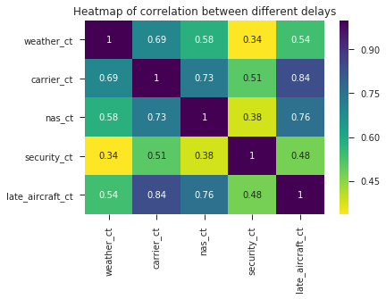

```python
# Select the variables to analyze
heatmap_data = df[['weather_ct', 'carrier_ct', 'nas_ct', 'security_ct', 'late_aircraft_ct']]
# Create a heatmap
sb.heatmap(heatmap_data.corr(), annot=True, cmap='viridis_r')
plt.title('Heatmap of correlation between different delays')

plt.show()
```

> Correlations between delay types, such as weather and carrier delays, highlight interdependencies.. strong positive corelation of 0.84 between carrier delay and delay due to late aircraft

**Visualize how flight delays change over time**

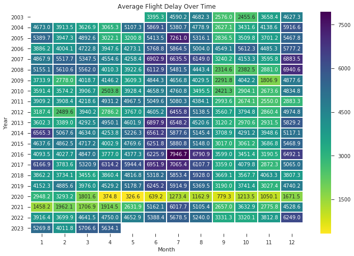

```python
#heatmap to visualize how flight delays change over time.
#Pivot the DataFrame to get average arrival delays by year and month
pivot_df = df.pivot_table(values='arr_delay', index='year', columns='month', aggfunc='mean')

# Create a heatmap
plt.figure(figsize=(12, 8))

sb.heatmap(pivot_df, cmap='viridis_r',annot=True, fmt=".1f", linewidths=1)
plt.title('Average Flight Delay Over Time')
plt.xlabel('Month')
plt.ylabel('Year')
plt.show()
```

> It can be noted that least average flight delay happened on the year of 2020 and generally during the months of june and july the average flight delay time is maximum

**Is there a relationship between Number of Weather Delays and Number of Security Delays**

```
Correlation between weather_ct and security_ct: 0.34
```

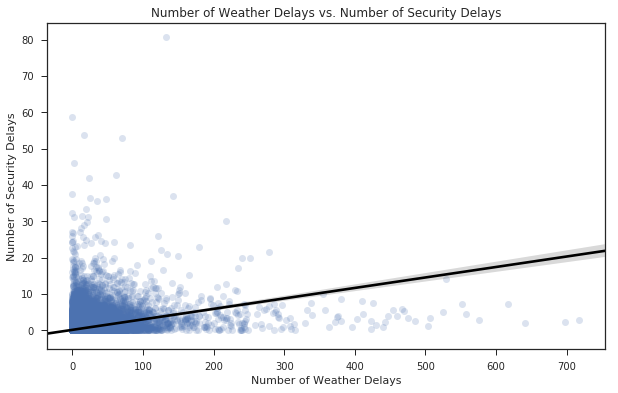

```python
plt.figure(figsize=(10, 6))
sb.regplot(x='weather_ct', y='security_ct', data=df, scatter_kws={'alpha': 0.2}, line_kws={'color': 'black'})

# Calculate the correlation
correlation = df['weather_ct'].corr(df['security_ct'])
print(f"Correlation between weather_ct and security_ct: {correlation:.2f}")

plt.xlabel('Number of Weather Delays')
plt.ylabel('Number of Security Delays')
plt.title('Number of Weather Delays vs. Number of Security Delays')

plt.show()
```

> Corelation between Number of Weather Delays and Number of Security Delays although positive, is very weak. 0.34.

### Talk about some of the relationships you observed in this part of the investigation. How did the feature(s) of interest vary with other features in the dataset?

> Various factors contribute to flight delays, including weather, security, and late aircraft arrivals. Different types of delays are positively correlated, meaning they often occur together. Some carriers might have stronger correlations between carrier and weather delays. There's a general trend where more flight arrivals coincide with more delayed flights. Monthly arrival counts doesnot vary much , suggesting non seasonal patterns in air travel.

### Did you observe any interesting relationships between the other features (not the main feature(s) of interest)?

> Monthly arrival counts doesnot vary much , suggesting non seasonal patterns in air travel. this was a bit surprising

## Multivariate Exploration

**what sort of relationship is there between canceled flights and total flights by month**

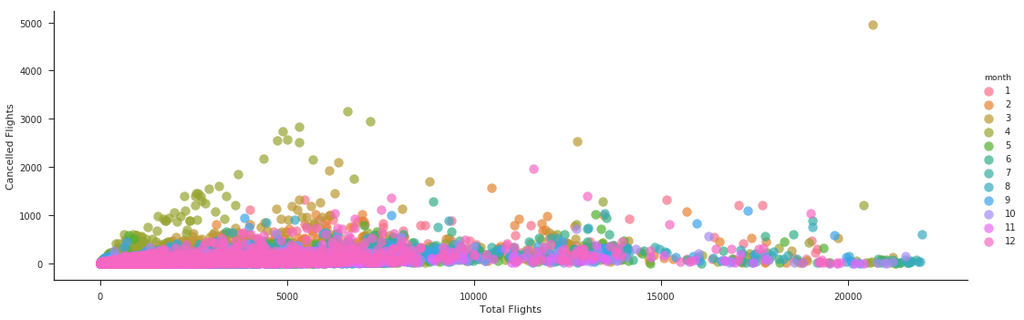

```python
#FacetGrid of scatter plots to visualize the relationship between canceled flights and total flights by carrier.

# Create a FacetGrid with carriers as the hue
g = sb.FacetGrid(df, hue='month',size=5, aspect=3)

#Map a scatter plot to the FacetGrid
g.map(plt.scatter, 'arr_flights', 'arr_cancelled', alpha=0.7, s=100)

g.set_axis_labels('Total Flights', 'Cancelled Flights')
g.set_titles('Cancelled Flights vs. Total Flights by month')
g.add_legend()

plt.show()
```

**visualize relationships between numerical columns in the dataset**

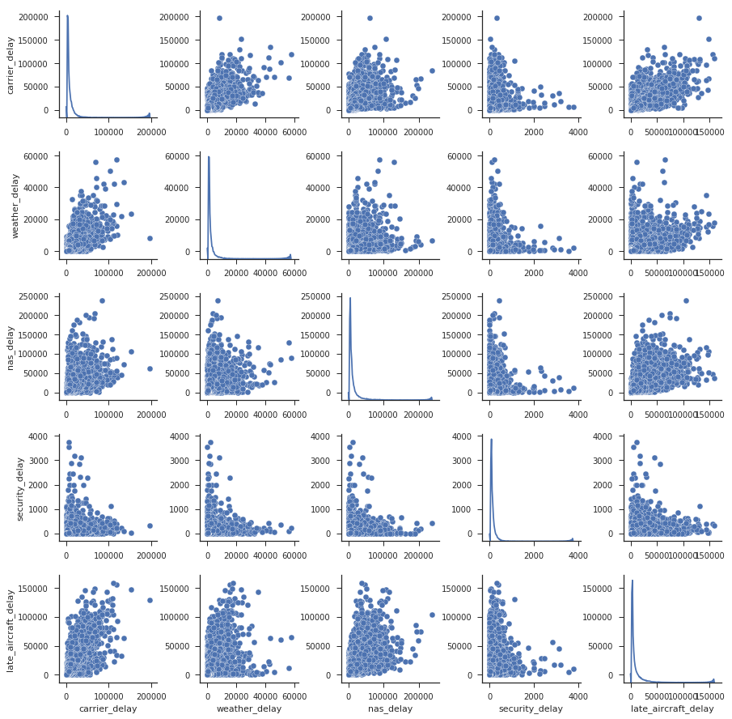

```python
# Select numerical columns for the scatter plot matrix
numerical_cols = [ 'carrier_delay', 'weather_delay', 'nas_delay', 'security_delay', 'late_aircraft_delay']

# Create a pairplot with diagonals as kernel density estimations (kde)
sb.set(style="ticks")
sb.pairplot(df[numerical_cols], diag_kind="kde")
plt.show()
```

> Correlations between delay types, such as weather and carrier delays, highlight interdependencies.. There is a strong positive corelation (0.76) between NAS delay and delay due to alte aircraft

### Talk about some of the relationships you observed in this part of the investigation. Were there features that strengthened each other in terms of looking at your feature(s) of interest?

> When visualizing relationships between numerical columns in the dataset, certain pairs, such as nas delay vs. late aircraft delay, positive correlations. This suggests that when one type of delay occurs, it may be accompanied by another type of delay.

## Conclusions

> Different carriers have varying total arrived flights, indicating differences in market share and scale. South west airlines has the most arrived flights

> 2020 has the most cancelled history. it may be due to the pandemic

> Late aircraft, NAS delays, and carrier-related issues are the most common causes of flight delays.

> period between 2007 and 2017 has seen a drop in total number of flights, reason for it has to be investigated further

> November month has the least amount of cancellations while january has the month

> Flights exhibit variations over the years, potentially influenced by seasonal factors.note:data is not complete for 2023

> There is not a much deviation in flight arrival over the different months.suggesting flight arrivals are not cyclical

> There is a strong positive corelation between the Number of Flight Arrivals and Number of Delayed Flights

> similarly there is also positive corelation between Carrier Delay and Weather Delay

> Comair Inc is the most affected by weather. Aloha Inc and Hawaiian Inc. are most affected by carrier-related issues

> Correlations between delay types, such as weather and carrier delays, highlight interdependencies.. strong positive corelation of 0.84 between carrier delay and delay due to late aircraft

> It can be noted that least average flight delay happened on the year of 2020 and generally during the months of june and july the average flight delay time is maximum

> There is also a strong positive corelation (0.76) between NAS delay and delay due to alte aircraft